# Inferring kin relationships with kinference

S M Baylis and M V Bravington

Package `kinference` uses SNP genotypes to find pairs of closely-related kin within a set of biological samples, presumably for use in Close-Kin Mark-Recapture. In this vignette, we:

1. demonstrate the core functions for kin-finding with a perfect dataset (section 1);
2. clean up a ‘typical’ dataset to get it to work for kinfinding (section 2);
3. and show *some* warning signs of Things Going Wrong (section 3).

Kinference can be pretty complicated, though it isn’t always. We can’t show everything here; this is actually a subset of a much larger evolving document, and we ourselves are still learning about the process as we throw new datasets with new problems at the software[^1]! There may be courses; check with the package maintainer. If you have questions, first have a look at the [Github Discussions page](https://github.com/orgs/closekin/discussions) for `closekin`, the parent Organisation of package `kinference`. Also, do look at `?kinference` inside R, plus of course the detailed documention of individual functions. This document makes reference in a few place to “the MS”, a long-awaited paper that gives details of all the algorithms used in this package. Unfortunately, the MS doesn’t quite exist at time of writing, but it is coming…

# Section 1: kin-finding

Here, we step through kin-finding with a well-behaved, well-cleaned dataset in `snpgeno` format. We will use the `dropbears` dataset included with package `kinference`. Some standard checks should *always* be done, but the `dropbears` dataset is already clean and won’t require any changes, and the allele frequencies have already been estimated. To see a dataset in need of cleaning (like yours!), see **Section 2**.

A dataset for kinference should have all of its samples drawn from a single, genetically-homogenous population, without any duplicate samples, samples from another population (or species!), or cross-contaminated or degraded samples. It also needs all loci to be “well-behaved”, ie in Hardy-Weinberg proportions, without substantial allelic dropout[^2] or genotyping errors, not duplicated, not under (strong) selection, etc.

## A quick look at the dataset

```r
library( mvbutils)     ## not sure if it needs to be explicitly loaded
library( gbasics)      ## so data objects behave nicely
library( atease)       ## convenient access to attributes; x@thing
library( kinference)
```

```r
kincol <- kinPalette() ## kin-specific colours, used later

## 'dropbears' is a dataset that comes with 'kinference'
## Very quick look at snpgeno data: covariates and some genotypes of a few samples
dim( dropbears)
```

```
## [1]  480 2000
```

```r
dropbears[1:3, 1:5]
```

```
##                                                    l   l   l   l   l
##                                                    o   o   o   o   o
##                                                    c   c   c   c   c
##                                                    u   u   u   u   u
##                                                    s   s   s   s   s
##                                                    _   _   _   _   _
##   Our_sample sex weight_kg    popn dropheight_m    1   2   3   4   5
## 1   sample_1   M     112.3     Tas            3   AB AAO AAO AAO  AB
## 2   sample_2   F     125.7     Tas            4  AAO  AB  AB AAO  AB
## 3   sample_3 Imm      96.6 Eastern            2  AAO AAO AAO AAO  AB
```

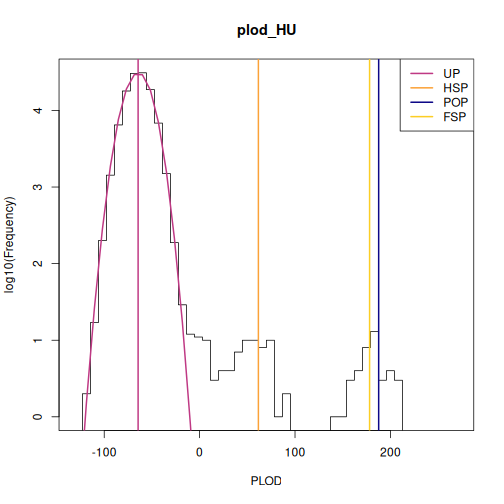

```r
## Boring but necessary data-prep:
dropbears <- kin_power(dropbears, k = 0.5)

plod_HU <- find_HSPs(dropbears, keep_thresh = 0)
histoPLOD( plod_HU, log=TRUE)
```

This plot shows observed log-densities of one kin-finding statistic (there are several) across all pairs of animals in the `dropbears` dataset, as the black stair-step lines. It also shows some vertical lines at the the predicted means for various kinships based on allele frequences, and the predicted distribution of unrelated pairs as a smooth purple curve. This is an excellent-looking kin space with all the bumps in all the right places - we’ll definitely be able to find kin pairs here.

## Finding and classifying kin pairs

From here, there are many potential workflows for finding kin pairs. The workflows can depend on demographic information (e.g., one might look for sibling pairs only among samples of young animals caught at a similar time, to reduce confusion from other kinships that are common in more general comparisons; or, first look for POPs only among pairs with a sizeable birth-year gap). Here, we show one potential workflow for kin-finding that does not use covariate/demographic information. We’re going to end up with four categories of pairs:

- POPs (Parent-Offspring Pairs)
- FSPs (Full-Siblings Pairs): collectively, POPs and FSPs constitute “first-order” kin, or 1KPs
- Definite 2KPs, (2nd-order Kin-Pairs, including Half-Siblings HSPs[^3], Grandparent-Grandchild GGPs, and full-thiatic[^4] FTPs), and
- “other”, which includes 3KPs, 4KPs, etc, all “Unrelated” Pairs (UPs), plus a proportion of 2KPs that didn’t look definite enough (“false negatives”).

The technical complication is that the simple and robust kin-finding statistics which we prefer, are all just for deciding just 2 kinships, eg POP vs FSP, or 2KP VS UP. But here we have at least 4 possible kinships overall. Thus the trick is to divide-and-conquer, splitting the collection of kin-pairs first into coarse groups and into finer ones. The workflow goes:

- find provisional POPs, ie all true POPs but potentially some FSPs too;
- within the provisional POPs, split definite POPs from FSPs;
- find provisional non-POP kin, including FSPs, 2KPs, 3KPs, and maybe some 4KPs, but hopefully no UPs;
- within those, split definite FSPs;
- identify a subset of (almost) definite 2KPs, and estimate the false-negative rate for that set.

Let’s begin.

## Find ‘strong’ kin pairs and split out POPs

We’ll start by doing pairwise comparisons of all samples, calculating a statistic designed to distinguish POPs from UPs or other types of kin. [Actually, two different POP statistics are available in ‘kinference’ now: the newer one, which might become the recommended option one after we’ve tested it more, is shown later, but we’ll start with the older one, which has been used in all our real-life CKMR applications to date.] This (older) statistic is called “wpsex” (weighted pseudo-exclusions: see MS) and takes values between 0 and 1: close to 0 for POPs, and higher for UPs or other kin. First, let’s get a global overview of the situation:

```r
# strongKin <- find_POPs(dropbears, limit_pairs=10000, keep_thresh=1)
strongKin <- find_POPs(dropbears,
   keep_thresh=0.1) # upper limit guess of "interesting" wpsex values in other studies
```

```
## Returning just the 240 pairs with most POP-like wpsex; increase 'limit_pairs' to get more
```

```r
# ... can disregard that limit_pairs warning *for now*, since this is just an overview

## What summary stats are there?
names( attributes( strongKin)) # or atts( strongKin) thx2 'atease'
```

```
##  [1] "names"          "row.names"      "class"          "bins"           "n_wpsex_in_bin"
##  [6] "eta"            "keep_thresh"    "n_loci"         "mean_UP"        "var_UP"
## [11] "call"
```

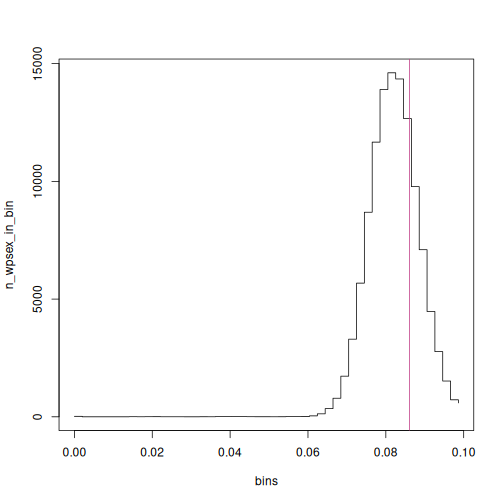

```r
## Overview plot for all pairs
with( attributes( strongKin),
    plot( bins, n_wpsex_in_bin, type='s' ))
abline( v=strongKin@mean_UP, col=kincol['UP'])
```

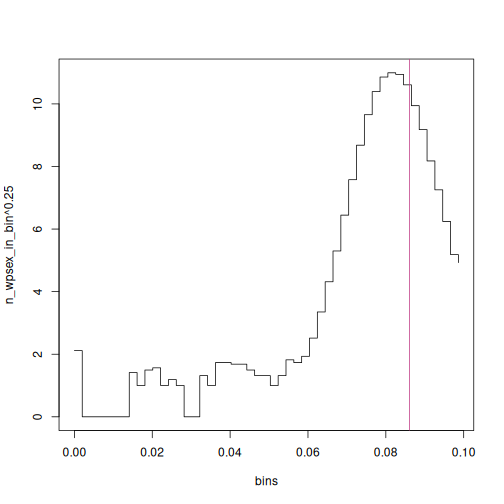

```r
## Not very informative, because the huge number of UPs masks the interesting stuff.
## Transform the y-scale...
## 0.25 power transform is a bit like log but copes with 0 (thanks: Bill Venables)
with( attributes( strongKin),
    plot( bins, n_wpsex_in_bin^0.25,
    type='s'))
abline( v=strongKin@mean_UP, col=kincol['UP']) # theoretical mean
```

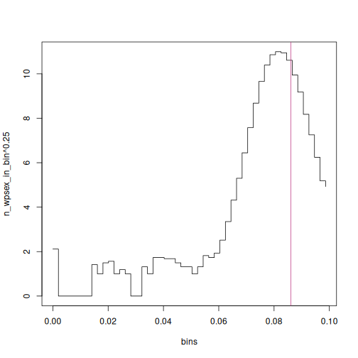

```r
## Zoom in on interesting region. First, re-run to make sure we get _all_
## the kin-pairs in that region, with no limit_pairs warning
strongKin <- find_POPs(dropbears,
   limit_pairs= 10000, # clearly less of them than that
   keep_thresh=0.07) # upper limit guess of "interesting" wpsex values in other studies

## ... and plot it again
with( attributes( strongKin),
    plot( bins, n_wpsex_in_bin^0.25,
    type='s'))
abline( v=strongKin@mean_UP, col=kincol['UP']) # theoretical mean
```

And we can clearly see a big bump of UPs on the right, a spike of about 20 pairs near zero, and in-between a few more bumps which will comprise FSPs, HSPs, and so on. The UP bump isn’t *quite* centred where purple theory says it should be[^5], but it’s close enough; let’s keep going. Based on those plots, we now pick some reasonable threshold of “interesting”, and then select all pairs below that threshold:

```r
## Select threshold for "worth investigating further". By eye.
UPcut <- 0.055

## Focus on those pairs:
strongest <- strongKin %where% (wpsex < UPcut)
# same as: strongest <- strongKin[ strongKin$wpsex < UPcut,]
dim( strongest)
```

```
## [1] 96  4
```

```r
## Show just top 5 then bottom 5 of these, for space:
head( strongest, 5)
```

```
##   wpsex   i   j nABOO
## 1     0 446 445     0
## 2     0 456 455     0
## 3     0 442 441     0
## 4     0 464 463     0
## 5     0 480 479     0
```

```r
tail( strongest, 5)
```

```
##         wpsex   i   j nABOO
## 92 0.05321628 372 371     0
## 93 0.05418490 296 295     0
## 94 0.05478877 224 223     0
## 95 0.05495167 210 209     0
## 96 0.05498302 316 315     0
```

Now we’ll calculate a statistic designed to separate POPs from FSPs[^6]. Note that we do have to specify a genotyping error rate (`gerr`) here— but the calculation is quite robust to mis-specification, so don’t worry. In *our* datasets, it’s been below 0.01 (1%), but *yours* might be different, of course. If your error rate is much higher than that, you probably won’t be able to use your dataset for kin-finding anyway.

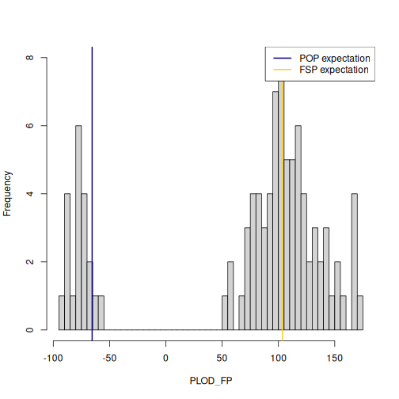

```r
splitPOPs <- split_FSPs_from_POPs( dropbears, strongest, gerr= 0.01)

hist( splitPOPs$PLOD_FP, breaks= 50, main= "", xlab= "PLOD_FP")
## Colours: kincol was set by call to kinPalette()
abline(v = splitPOPs@E_FSP, col = kincol['FSP'], lwd = 2)
abline(v = splitPOPs@E_POP, col = kincol['POP'], lwd = 2)
legend("topright", legend = c("POP expectation", "FSP expectation"),
    lty = c(1,1), lwd = c(2,2),
    col = kincol[ c('POP', 'FSP')], bg = "white")
```

```r
## Clump in [-50,-100] are POPs;
## rest a mix of FSPs, HSPs, and possibly weaker kin.

POPs <- splitPOPs[splitPOPs$PLOD_FP < 0,] ## our first set of definite kin pairs
POPs$ij <- upairid(POPs$i, POPs$j) ## a pair ID
```

We now have a set of definite POPs; next we need to find FSPs and 2KPs.

## Find definite FSPs

We can’t go straight from the POP results in `strongest` because the FSPs may not all be in `strongest` (their “wpsex” score may not have fallen below that `UPcut` threshold in the first place). So we start by provisionally identifying “all interesting kin” (1KPs and 2KPs, but perhaps with some 3KPs etc mixed in), taking out the POPs that we already have, and then separating the remainder into FSPs vs “the rest”. The tool for the job is `find_HSPs`, which we already used for a quick overview of all kinships. This time we should be a bit more careful with the arguments because we want to select specific pairs, so here’s some detail.

`find_HSPs`— which should really be called `find_2KPs`— keeps binned counts of PLODs for all pairwise comparisons, but only keeps individual PLODs for those pairs whose PLOD is above `keep_thresh`, which we will need to set[^7] Before calling `find_HSPs`, we can find the expected PLOD for an UP, which will be negative. It so happens that the expected PLOD for an 2KP is roughly the absolute value of the UP mean, and for a 3KP the expected PLOD is close to 0. If kinference is going to work, the 2KP bump should be well to the right of the 3KP mean, so choosing `keep_thresh` just below 0 (ie at a small proportion of the UP mean) should keep the interesting stuff without too much rubbish. It’s also a good idea to set `limit_pairs` argument, so that the computer doesn’t try to retain zillions of actually-unimportant kin in case we set `keep_thresh` too low; 10000 should be fine. With all that in mind, here we go:

```r
## find HSPs-or-stronger using find_HSPs

## Expected PLOD for UPs (thanks to 'kin_power' earlier):
sum( dropbears$locinfo$E_UP)
```

```
## [1] -64.47591
```

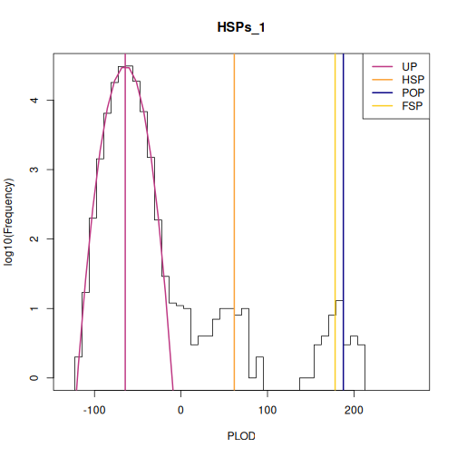

```r
## So "-10" should be OK for keep.thresh here. Guard against keeping too many:

HSPs_1 <- find_HSPs(dropbears, keep_thresh = -10, limit_pairs=10000)

## plot the counts of PLODs in bins, on a log_10 scale so we can actually see the bumps:
histoPLOD( HSPs_1, log=TRUE)
```

Note the general pattern - there is a large bump of UPs, with mean and variance exactly where theory predicts them to be, and bumps for 2KPs and 1KPs (ie, FSP as well as POP) centred exactly where theory expects[^8]. There’s also a “shoulder” around 0, between the UP and 2KP bumps, which is just where we’d expect 3KPs to be. This is a good dataset.

Now we can zoom in on just the individually-kept PLODs for the retained pairs. We want an unlogged plot, so we must set `lb` to be the lower bound on displayed PLODs (to exclude the huge bump). The unlogged version shows actual retained PLODs, not bin-counts, so there’s no point in setting `lb` below the previous `keep_thresh`. We also need to set `fullsib_cut` by eye, anywhere in the air-gap that is hopefully between 1KPs and 2KPs (it’s not vitally important where; see ‘?histoPLOD’ for more).

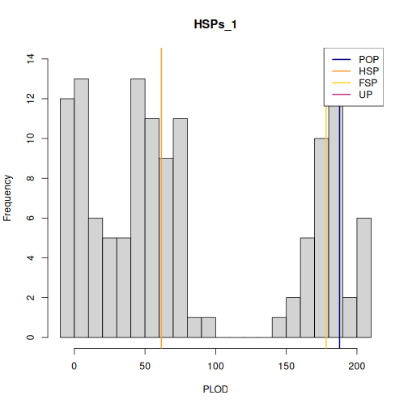

```r
# 'bin' sets bin width for histo
histoPLOD( HSPs_1, log=FALSE, fullsib_cut = 120, lb = -10, bin = 10)
```

The PLOD in `find_HSPs` doesn’t itself discriminate well between FSPs and POPs, but there is a clear gap between 1KPs and 2KPs. Any 1KPS that *aren’t* POPs must be FSPs, so we can pick all 1KPs using this PLOD, subset out the POPs that we already found, and be left with the FSPs.

```r
POPsOrFSPs <- HSPs_1[HSPs_1$PLOD > 110,]           ## anywhere in the valley
POPsOrFSPs$ij <- upairid(POPsOrFSPs$i, POPsOrFSPs$j) ## pair ID to match the one in POPs
FSPs <- POPsOrFSPs[!POPsOrFSPs$ij %in% POPs$ij,]   ## find our FSPs
```

Now, we have our set of POPs, our set of FSPs, and a set of tentative 2KPs. Again, those “second-order kin” comprise half-sibling, grandparent-grandchild, and full-thiatic pairs: we cannot split between those genetically[^9], but in many CKMR applications, covariate data such as ages can do the job. In this particular case, the 2KPs will almost all be HSPs, on demographic grounds (details out of scope here). However, the bigger issue is that the set of tentative 2KPs may well be contaminated by more-distant kin, mainly 3KP (half-thiatic and great-grandparent-grandchild pairs) and 4KP (e.g. half-first-cousin pairs). We have already gotten rid of the 1KPs, but for the rest we now need to decide on a PLOD cutoff above which we will treat everything as “definite 2KP”. We will then use the distribution of PLODs among those “definite 2KPs” to work out how many false-negative 2KPs are likely to have fallen below the cutoff. Unlike with 1KPs vs 2KPs, there won’t be a clean break, so things get a bit more complicated.

The idea of choosing the cutoff is to let us retain a (hopefully large) proportion of true 2KPs, subject to a tolerance on the expected number of contaminating 3KPs and 4KPs that by chance fall above the threshold. That tolerance is up to you; you really don’t want many false-positives from 3KPs because they can mess up a CK model. The problem isn’t the *number* of false-positives; rather, it’s the different dynamics that different kinships have. Most of all, 3KPs tend to have much longer birth-gaps than HSPs, so that mislabelling even a couple of 3KPs as “HSPs” can cause a substantial bias in mortality-rate estimates. (Note that it doesn’t cause bias to discard some true 2KPs below the cutoff, because we can compensate by incorporating the estimated false-negative rate directly into the CKMR model.) While it’s a good idea to choose a high cutoff (i.e., few false-positives) to minimise the bias from 3KPs, there is a trade-off; higher cutoffs do lead to fewer definite 2KPs going into the model, and thus to higher variances, as well as making it harder to check model diagnostics. Nevertheless, you should certainly go high enough to get your estimated false-positive rate well *below* the false-negative rate; you defintely *don’t* want “equal probabilities” here.

We have often chosen the cutoff at a round number by eye, but a more systematic approach is via the `autopick_threshold` function. This takes the empirical distribution of PLODs in the tentative HSPs, estimates the impact of linkage, and— on the assumption that each comes from either a HSP, HTP, or half first cousin pair (H1CP)— fits a constrained mixture decomposition (see function documentation and MS for details) to estimate the underlying distributions and numbers of HSPs/HTPs/H1CPs, before numerically choosing a cutoff to achieve the desired tolerance.[^10] When `autopick_threshold` works well, it’s great; but don’t trust its output if it doesn’t look sensible, because it may have too much flexibility in fitting especially when the number of kin-pairs is low. Whether-or-not you use `autopick_threshold`, the process *is* intrinsically subjective, because *you* have to decide how many 3KPs you are willing to tolerate. So, picking a cutoff by eye is also OK (because the false-negative rate computed afterwards will eliminate bias), as long as you don’t try to “tweak” the cutoff to include/exclude specific pairs.

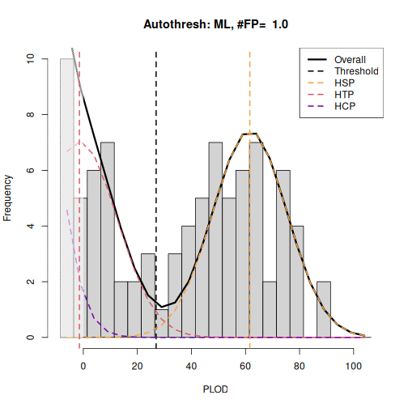

```r
HSPs_1$ij <- upairid(HSPs_1$i, HSPs_1$j)
HSPs_2 <- HSPs_1[!HSPs_1$ij %in% c(POPs$ij, FSPs$ij),]
## plot the empirical PLODs with the expected distribution
## of the PLOD for half-sibling pairs
thresh <- autopick_threshold( dropbears, kin = HSPs_2, fitrange_PLOD = c(0, 110),
    FPtol_pairs = 1, # tolerate 1 expected false-positive
    use4th = TRUE, selecto = "ML", plot_bins = 5)
```

```r
thresh
```

```
## [1] 26.94363
## attr(,"fitrange_PLOD")
## [1]   0 110
## attr(,"selecto")
## [1] "ML"
## attr(,"use4th")
## [1] TRUE
## attr(,"FPtol_pairs")
## [1] 1
## attr(,"info")
##        V0_M3        Vx_M3        V0_M4        Vx_M4         V_UP        V_HSP        C_hat
## 179.66091016 192.07090954 162.47650979 166.37340040 135.90524760 185.86912547 211.68747051
##      rho_hat           E2           E3           E4          SD2          SD3          SD4
##   0.05300852  61.60599802  -1.43495747 -32.95543522  13.63338276  13.85896495  12.89858133
##           P2           P3           P4           N3         Nall       thresh      Pr_FNeg
##   0.14357251   0.13856494   0.71786255  49.27040441 355.57627543  26.94363293   0.00550372
```

Well, that plot looks great! With that cutoff, we can select our “definite 2KPs” and the estimated false-positive and false-negative rates of that set:

```r
HSPs <- HSPs_2[HSPs_2$PLOD > thresh,]
fpos_rate <- thresh@FPtol_pairs / nrow(HSPs) ## ~2% of our 'HSPs' are false-positives
fneg_rate <- thresh@info["Pr_FNeg"]
## we're missing about 0.5% of HSPs to false-negatives;
## _extremely_ good, expect 10--20% yourself!
nrow(HSPs) ## 52 inferred likely half-sibling pairs
```

```
## [1] 52
```

## Examine covariates of kin-pairs data

It’s almost always useful to look at the covariates of the kin-pairs, which typically have a different distribution to the covariates of typical samples. Those covariates are essential for subsequent CKMR models.

```r
summary( dropbears$info[ c( HSPs$i, HSPs$j), ]) ## samples in HSPs
```

```
##   Our_sample            sex              weight_kg          popn            dropheight_m
##  Length:104         Length:104         Min.   : 47.30   Length:104         Min.   : 0.000
##  Class :character   Class :character   1st Qu.: 84.42   Class :character   1st Qu.: 2.000
##  Mode  :character   Mode  :character   Median :101.30   Mode  :character   Median : 3.000
##                                        Mean   : 98.88                      Mean   : 3.442
##                                        3rd Qu.:116.40                      3rd Qu.: 4.000
##                                        Max.   :138.50                      Max.   :10.000
```

```r
summary( dropbears$info)              ## all samples
```

```
##   Our_sample            sex              weight_kg          popn            dropheight_m
##  Length:480         Length:480         Min.   : 29.00   Length:480         Min.   : 0.000
##  Class :character   Class :character   1st Qu.: 88.72   Class :character   1st Qu.: 2.000
##  Mode  :character   Mode  :character   Median :107.85   Mode  :character   Median : 3.000
##                                        Mean   :102.02                      Mean   : 3.498
##                                        3rd Qu.:119.03                      3rd Qu.: 5.000
##                                        Max.   :161.10                      Max.   :10.000
```

## Alternative POP statistic

Incidentally, here’s the newer POP statistic in action. You need to specify some genotyping error rate, as with `split_FSPs_from_POPs`, but again any reasonable choice should lead to the same final set of POPs.

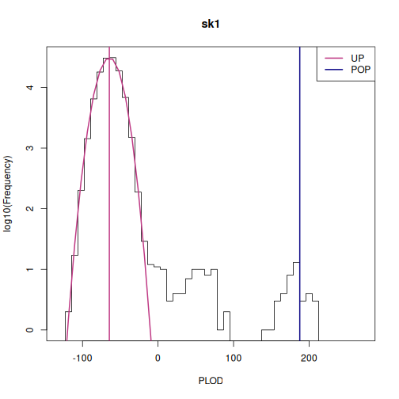

```r
## Assume modest error rate
sk1 <- find_POPs_lglk( dropbears, gerr= 0.01, limit_pairs= 200, keep_thresh= -5)
histoPLOD( sk1, log=TRUE)
```

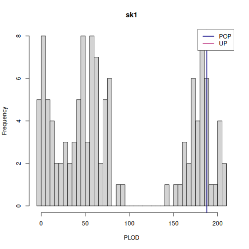

```r
histoPLOD( sk1, log=FALSE, lb=-5)
```

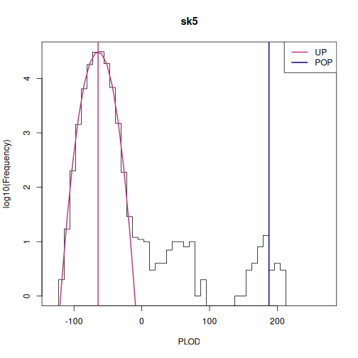

```r
## Assume bad error rate
sk5 <- find_POPs_lglk( dropbears, gerr= 0.05, limit_pairs= 200, keep_thresh= -5)
histoPLOD( sk5, log=TRUE)
```

# Section 2: cleaning the bluefin dataset

Your data will almost certainly need cleaning before you can do the kin-finding in Section One. To show how (and, in **Section 3**, *why*), we’ll use the `bluefin` dataset included in package `kinference`.

## Population allele frequencies

Many of the functions in `kinference` require a `snpgeno` with pre-computed population allele frequencies for each locus, stored in an object called `pbonzer`. The `bluefin` dataset has its allele frequencies pre-computed based on a larger version of the dataset, so we won’t recompute them, but here’s how to do it:

```r
# 'bluefin' is a dataset that comes with 'kinference'
# Check genotype encoding:
diplos( bluefin)  # aha, 6-way genotyping (legacy CSIRO data)
```

```
## [1] "AA" "AB" "AO" "BB" "BO" "OO"
```

```r
## if you're using 4-way genotypes(most likely)
## bluefin <- est_ALF_ABO_quick( bluefin)

## if your data are stored 6-way:
## ('bluefin' is 6-way, but 'dropbears' is 4-way)
## bluefin <- est_ALF_6way( bluefin) # needs extra info too
```

Some loci may have an estimated A or B allele frequency of zero, which can cause problems. It is best to drop loci with very low estimated A or B allele frequencies - they wouldn’t be very informative anyway.

```r
bluefin <- bluefin[ , bluefin$locinfo$pbonzer[ ,"A"] > 1e-6]
bluefin <- bluefin[ , bluefin$locinfo$pbonzer[ ,"B"] > 1e-6]
```

## Checking for badly-behaved loci

```r
pvals <- check6and4(bluefin, thresh_pchisq_6and4 = c(1e-4, 1e-6), show6 = FALSE)
```

```
## genotypes are stored 6-way. Doing both 6-way and 4-way GOF tests...
```

```
## calculating both 6-way and 4-way pvals, plotting 4-way...
```

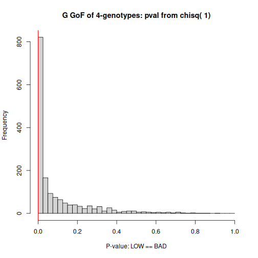

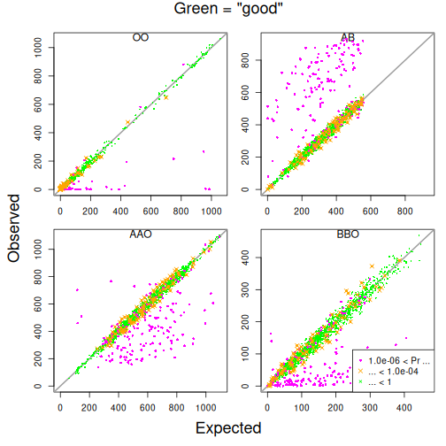

Those ‘thresh…’ values are entirely subjective, and dataset-dependent. They just control which points get coloured, so you can experiment til you find a threshold that excludes the loci you feel are visually unacceptable. (The real “proof of the pudding” comes much later, when you check whether ‘find_HSPs’ is looking OK. You should expect that this whole QC process will need to be iterative!)

We can see that most loci in this dataset lie pretty close to the “observed = expected” line for all four genotypes - but some of them are off the mark. In real datasets, it is wise to have a little wriggle-room: this dataset may still contain duplicate samples, fish from another population, or contaminated or degraded samples - and each of those can contribute to the *loci* having lower-than-expected P-values. However, some of these loci are just abysmal - bad fish will make all loci look bad, but they generally won’t make a few particular loci look *really bad*. The abysmal-looking loci almost certainly aren’t the result of a few bad fish. So for now, we will just remove loci with P < 1e-10. After the rest of the cleaning stages, we can (and will!) revisit these P-values without the bad samples.

```r
bluefin_1 <- bluefin[, pvals$pval4 > 1e-10]
pvals_1 <- check6and4(bluefin_1, thresh_pchisq_6and4 = c(1e-4, 1e-6), show6 = FALSE)
```

```
## genotypes are stored 6-way. Doing both 6-way and 4-way GOF tests...
```

```
## calculating both 6-way and 4-way pvals, plotting 4-way...
```

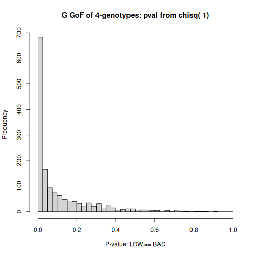

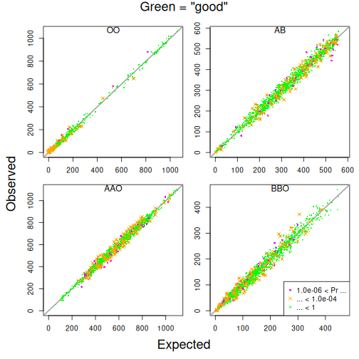

```r
## pvals_1 is storage so we can check back on the same scores later
```

## Finding and removing duplicate samples

Now, let’s check for duplicate samples

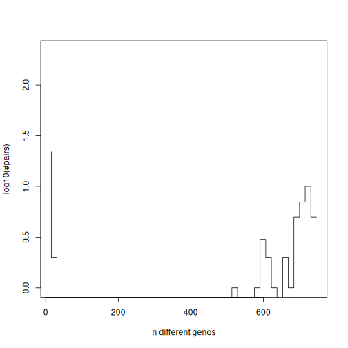

```r
## look for duplicates, noting any pairs with <50 different genotypes:
dups <- find_duplicates(bluefin_1, max_diff_loci = 50)
```

```r
nrow(dups) ## 24 pairs of animals with fewer than 50 different genotypes
```

```
## [1] 24
```

We’ve got 24 pairs of animals with fewer than 50 different genotypes - but nearly all of our animal pairs have more than 500 different genotypes, and there’s a huge air-gap between 40 and 500 with no animal pairs. The 24 pairs with less than 50 different genotypes are almost certainly duplicates. (On your own dataset, you should of course check covariates at this point to confirm.) Anyway, quite often “duplicates” actually turn out to be triplicates etc, but ‘kinference’ only records pairwise results. When we have duplicates or triplicates or whatever, we only need to keep one from each set. `kinference` contains a convenient function - `drop_dups_pairwise_equiv` - to help us do exactly that:

```r
bluefin_2 <- bluefin_1[ -c( drop_dups_pairwise_equiv( dups[,2:3])),]
```

## Samples from another population or species

Now, we need to find and remove any outlying “animals not like the others”. These may be animals from another species or population that have somehow made it into our dataset, or they might be badly degraded or contaminated, or something might have gone wrong with extraction or sequencing for that sample, or so on and so forth. Animals that don’t look like they’re drawn from the same population as everyone else aren’t usable for kinference, at least not with this software.

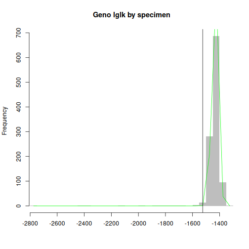

```r
ilglk <- ilglk_geno(bluefin_2)
abline(v = -1525) ## put our cutoff here
```

This pattern of `ilglk_geno` scores is pretty typical when most samples are correctly identified, but there are a handful of animals from a distantly-related stock or another species in the dataset: there is a large, approximately Normally-distributed, spike at the right-hand side of the plot, and a long tail strung out to the left, containing the animals from another stock or species. In our case, any animal with an ilglk score less than -1525 or so is not believable as a member of the same stock as the main spike. Let’s remove them.

```r
bluefin_3 <- bluefin_2[ilglk > -1525,]
## now, does it look any better?
ilglk <- ilglk_geno(bluefin_3)
```

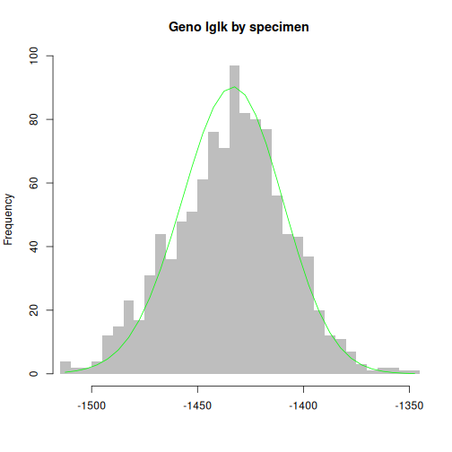

```r
## Yes! Now re-do that important but boring internal calculation
bluefin_3 <- kin_power(bluefin_3, k = 0.5)
```

## Cross-contaminated and degraded samples

Now, we need to *try* to find and remove cross-contaminated or degraded samples. Checking for excess or deficiency of heterozygosity is the way to go here, but there some subtle details to do with null alleles and so on; see MS[^11]. The function for this is `hetzminoo_fancy`, which has a “rich” variant optimized for finding contamination, and a “poor” variant for degradation. With “rich”, you’re looking for too-big values; with “poor”, for too-small values— although it must be said that the two variants tend to look pretty similar.

```r
hetzpoor <- hetzminoo_fancy(bluefin_3, "poor") ## ... maybe a couple of outlying low samples
```

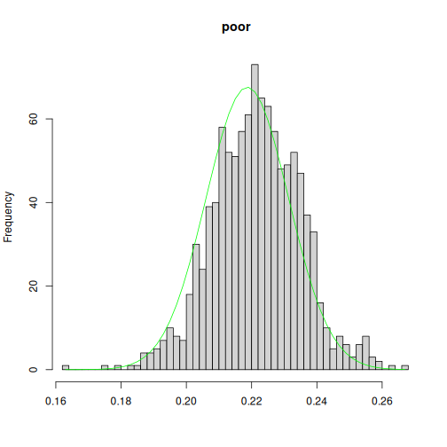

```r
hetzrich <- hetzminoo_fancy(bluefin_3, "rich") ## ... maybe no high ones (debatable!)
```

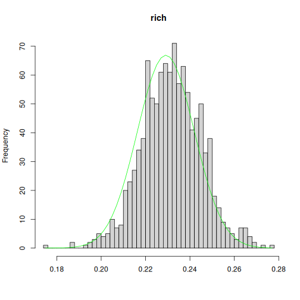

```r
bluefin_4 <- bluefin_3[hetzpoor > 0.17,] ## remove the outlying low hetzpoor scores
hetzpoor <- hetzminoo_fancy(bluefin_4, "poor") ## Hey, the hetzpoor outliers are gone!
```

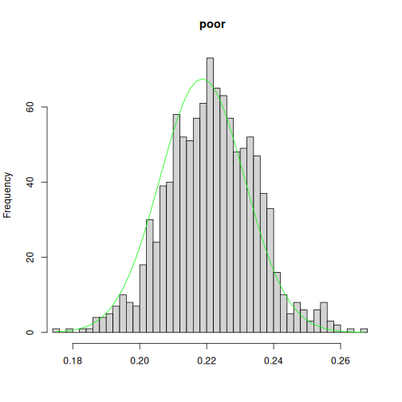

That was actually pretty good data (after initial cleanups)— the heterozygosity outliers weren’t particularly drastic and there weren’t many. We could have gone a bit safer by trimming a few more “outliers”, but let’s keep going with what we now have.

## How has removing bad fish impacted our apparent locus quality?

Remember how I mentioned that having bad *samples* in the dataset can make *loci* look bad? Let’s take a look at the P-values for individual loci we stored earlier, re-calculate them now that we’ve removed all the bad fish, and see whether the loci look any better.

```r
pvals_2 <- check6and4(bluefin_4, thresh_pchisq_6and4 = c(1e-4, 1e-6), show6 = FALSE)
```

```
## genotypes are stored 6-way. Doing both 6-way and 4-way GOF tests...
```

```
## calculating both 6-way and 4-way pvals, plotting 4-way...
```

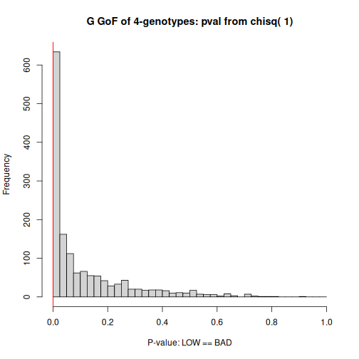

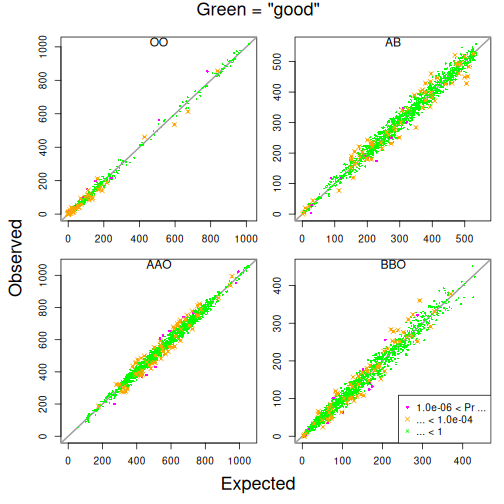

```r
lociPvals <- data.frame(
    pvals = c(pvals_2$pval4, pvals_1$pval4),
    stage = c(
        rep("after", length(pvals_2$pval4)),
        rep("before", length(pvals_1$pval4)))
  )
lm1 <- lm(pvals ~ stage, data = lociPvals)
summary(lm1)
```

```
##
## Call:
## lm(formula = pvals ~ stage, data = lociPvals)
##
## Residuals:
##      Min       1Q   Median       3Q      Max
## -0.11292 -0.10324 -0.07165  0.04540  0.81516
##
## Coefficients:
##              Estimate Std. Error t value Pr(>|t|)
## (Intercept)  0.112922   0.004010  28.160   <2e-16 ***
## stagebefore -0.007792   0.005671  -1.374     0.17
## ---
## Signif. codes:  0 '***' 0.001 '**' 0.01 '*' 0.05 '.' 0.1 ' ' 1
##
## Residual standard error: 0.1549 on 2984 degrees of freedom
## Multiple R-squared:  0.0006323,  Adjusted R-squared:  0.0002974
## F-statistic: 1.888 on 1 and 2984 DF,  p-value: 0.1695
```

Removing bad fish has caused a small improvement in the apparent quality of our loci: the average locus in our dataset has seen its P-value increase by 0.008. This is why we didn’t want to be *too* harsh in trimming loci early in our cleaning pathway - we would have removed loci that were actually fine, but looked bad because of the bad fish, and that would have cost us power by reducing the number of good loci we use for kin-finding. If you *really* want to refine your locus-selection to keep as many as possible, you might try a *very* lenient cutoff for locus quality, then look for very bad samples, then tighten the locus quality cutoff, then look for bad samples again.

Another approach is to be *very* stringent initially with both loci *and* samples, then progressively re-check whether some loci and some samples can be re-admitted to the “good club”. Wait for the book!

## Kinfer the bluefin dataset

The `bluefin` dataset is now cleaned. We won’t go through the full kin-finding routine again here - it would be the same as for `dropbears` (see **Section One**). I’ll just show you the “histoPLOD”, so you can see that kin-finding would now work for `bluefin`, cleaned as it is.

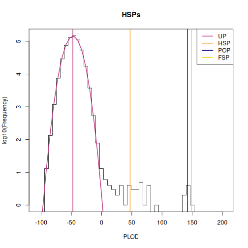

```r
## As outlined in Section 1, `keep_thresh` sets a PLOD limit to
## prevent storing umpteen-millions of PLODs. Negative 10 i s a often
## about right, but you may need to set it lower (to store more PLODs)
## or higher (to save RAM or make histoPLODs prettier)
HSPs <- find_HSPs(bluefin_4, keep_thresh = -10)
histoPLOD( HSPs, log=TRUE)
```

This histoPLOD shows a spike of unrelated pairs that is well-characterised by its expected distribution, a spike in density where we would expect to see half-siblings, and another spike in density where we would expect FSPs or POPs. From this, it should be clear that we can kinfer this dataset using the same approach as in Section One, albeit with slightly less power.

# Section Three: do we *really* need to do all that cleaning?

In this section, we demonstrate a handful of things that can go wrong in a kinference analysis, and suggest ways to deal with them. This set of examples is not exhaustive! If you have a problem that is not dealt with in this section, you can try getting in touch with experienced kinferencers, including the maintainer of package `kinference`, at the [Github Discussions page](https://github.com/orgs/closekin/discussions) for `closekin`, the parent Organisation of package `kinference`.

Offscreen, I’ve prepared versions of the `bluefin` dataset with all-but-one of the cleaning steps. For example, `bluefin_exceptIlglk` has had its loci checked, has had duplicates removed, had its contaminated and degraded samples removed - but I’ve kept all the samples that failed our check for animals from another population, using `ilglk_geno`. I’ve also built `bluefin_exceptDuplicates`, `bluefin_exceptHetzPoor`, `bluefin_exceptHetzRich`, and `bluefin_except6and4`, each of which has skipped the obvious cleaning step. Here, we’ll walk through the sorts of things you might see if your data aren’t properly cleaned.

## Duplicates

*In principle*, there are two reasons we don’t want duplicate samples in our kin-finding dataset: first, because our null distributions for our various kin-finding statistics are calculated under the assumption that each sample is drawn independently and at random from the sampled population. Duplicate samples, especially if they account for a large proportion of the dataset, will make those null distributions and decisions based on them inaccurate. Second, if you follow the kin-finding pathway shown in this vignette, and have duplicate samples in your dataset, and don’t check your results carefully, those dups will be mistaken for POPs.

Duplicate pairs are very easy to spot: they look more closely related than any true kin pair, so they appear far off to the right of the histoPLODs (they might not be visible on the unlogged version though, because it sets its xlim internally and will cut off massive outliers). The `bluefin` dataset doesn’t have all that many duplicates, so the differences to the null distributions aren’t pronounced.

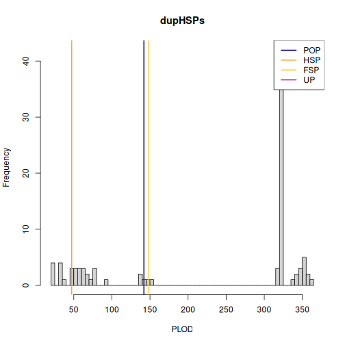

```r
dupHSPs <- find_HSPs(bluefin_exceptDups, keep_thresh = -10)
## histoPLOD( dupHSPs, log=TRUE) # use the logged version to pick the fullsib_cut
histoPLOD( dupHSPs, log=FALSE, lb = 20, fullsib_cut = 150)
```

## Samples from another population or species

Samples from another population or species will look very unlike the bulk of the other samples, so pairs with one animal from population A (the intended population) and another from population B (the unintended population) will tend to have very un-kin-like kinship scores. On the other hand, pairs between two samples from population B *may* have very high kinship scores, especially if some loci have alleles that are rare in population A but more common (or even fixed) in population B.

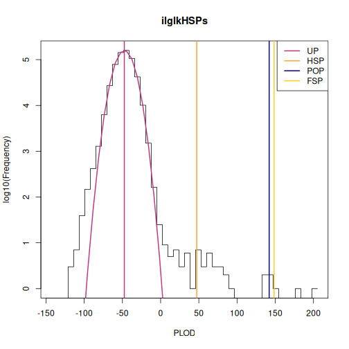

```r
# par(mfrow = c(2,1))
ilglkHSPs <- find_HSPs(bluefin_exceptIlglks, keep_thresh = -10, minbin = -150)
## there are a bunch of 'less related than expected' fish in the low tail
## of the unrelated pair bump.
histoPLOD( ilglkHSPs, log=TRUE)
```

Note both the bump out to the left of the unrelated pairs. There may also be additional pairs scattered throughout the ‘kin-like’ regions of the PLOD distribution (although it’s not particularly apparent in this dataset), but these pairs in the ’kin-like- regions will not closely match the expected peak locations for any particular kin group except by accident.